# Accountability and Information 1

Final Project Essentials: Fixed Effects

Carolina Torreblanca

University of Pennsylvania

**Global Development**: Intermediate Topics in Politics, Policy, and Data

PSCI 3200 - Spring 2026

# Logistics

## Assignments

- Today
  - Jablonski and Seim (2023)
  - Questions about Data Assignment 1
- Thursday (3/28)
  - Data Assignment 1 Due
  - Dunning et al. (2019)

## Agenda

1. Jablonski and Seim (2023)
2. Data Assignment 1 Questions
3. Final Project Essentials: Fixed Effects

# Jablonski and Seim (2023)

## Models of political accountability

**What is political accountability?**

- Accountability is meant to produce *responsiveness*
- Responsiveness means that a government “adopts policies that are signaled as preferred by citizens” (Manin, 1999)
- If governments fail to adopt citizens’ preferred policies, they will be sanctioned

**Assumptions**

- Politicians have information about what citizens want
- Citizens have information about which policies a politician is responsible for

## Models of political accountability

**Accountability requires that Voters:**

- Observe credible signal of performance
  - Attribution
  - Benchmarking
- Update their beliefs
- Have credible alternatives

## Models of political accountability

**Accountability requires that politicians:**

- Seek to maintain office
- Observe citizen preferences
- Update their beliefs

## Models of political accountability

**Distributional politics**

- Target public spending to maximize electoral advantage

**Responsiveness**

- Maximizing welfare across constituents

**Decentalization**

- Both sides have better information at a more local level

## Background

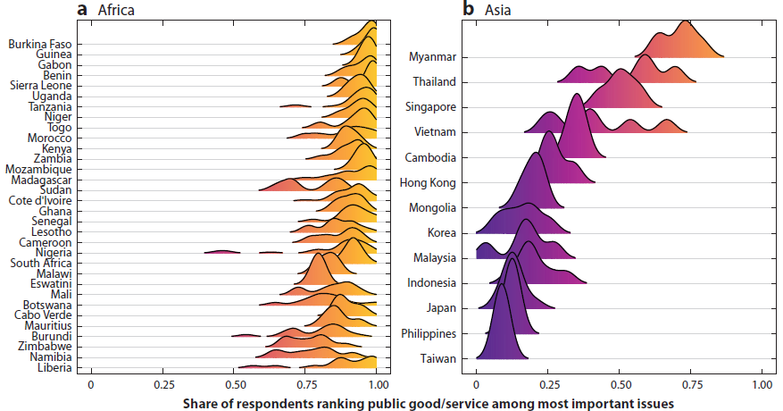

## Background

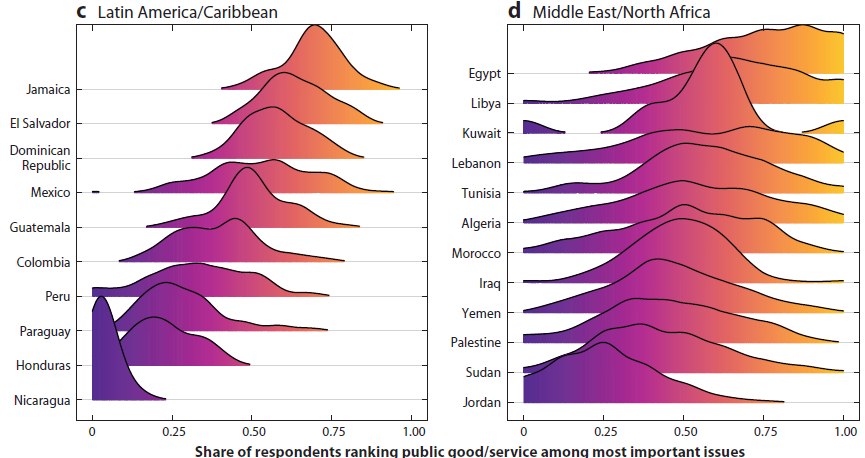

## Theory

- Politicians aim to allocate to the community with the highest return on votes
- This means that allocation is conditional on information about citizen preferences across eligible communities

**Citizen utility**: $x_i = c_i(a) - p_i - d_i$

- $c_i(a)$: Utility from investment $a$
- $p_i$: Utility of voting for a challenger
- $d_i$: Cost of voting

## Theory

**Politician utility:**

$$v_j(a) = \sum_{i=1}^{N} 1(x_i > 0, p_i + d_i \geq 0)$$
To allocate on electoral rewards, they need to know:

- $c_i(a)$: Utility from investment $a$
- $p_i$: Utility of voting for a challenger
- $d_i$: Cost of voting
- $n$: The number of individuals

## Theory

**Gathering information is costly**

- Time
- Coordination
- Varies across constituencies (geography, social proximity)

**Alternatives**

- Rely on heuristics
- Collect information from more accessible places

## Theory

**By providing information to politicians, we can see how the lack of information affects allocation decisions**

## Research Design

**Information about schools**

- Need: Class size, teacher housing, etc.
  - Target communities with high consumption utilities ($c_i(a)$)
- Aid: Existing aid projects at each school
  - Marginal returns to overlapping investments
- Voting: Vote share at nearest polling station
  - Update on $\bar{p_j}$
  - $d$ determines whether to mobilize swing or base

## Research Design

**Outcome**

- Allocation of NGO supplies

**Heterogeneous effects**

- Transparency
- Information costs

## Research Design

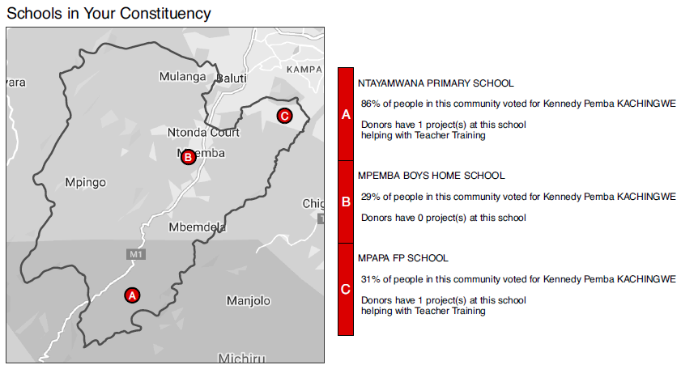

## Research Design

**Questions**

- What do they mean by ‘factorial assignment’?
  - Each respondent has 1-3 pieces of information
- In the estimation, how are they using interaction terms?
  - Estimate the impact of information based on provision
  - Estimate heterogeneous effects based on information costs and transparency

$$P(Y_{nsi} = 1) = \phi(\beta_1z_i + \beta_2t_sz_i + \gamma X_is + e_{nsi})$$

## Description of Information

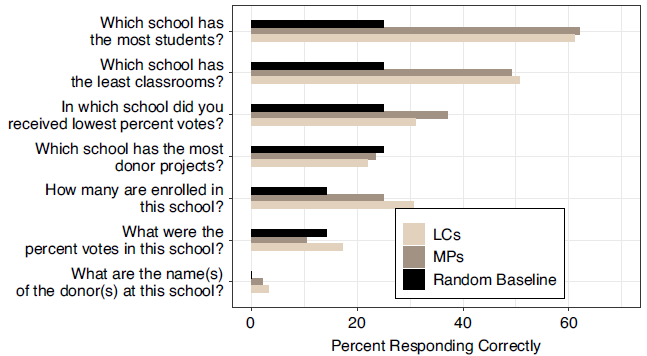

## Findings

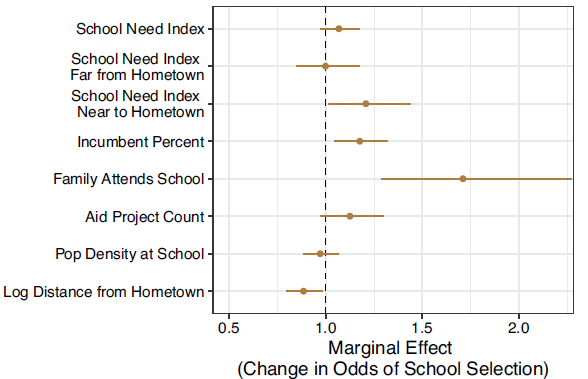

## Findings

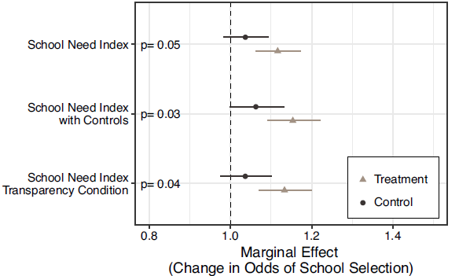

## Findings

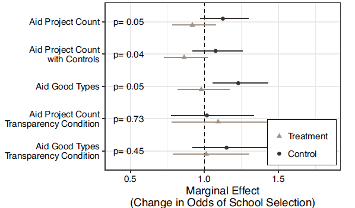

## Findings

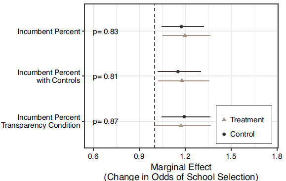

## Findings

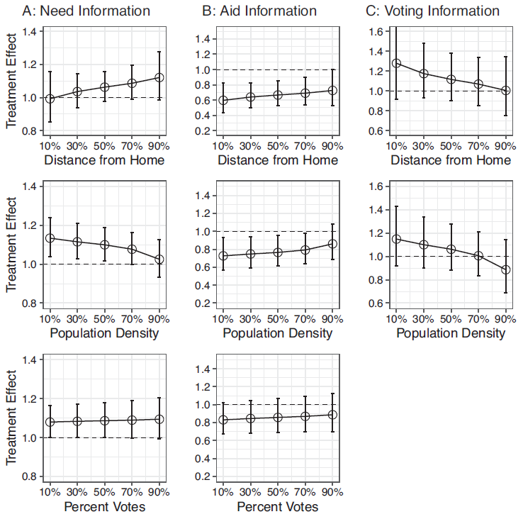

## Policy Implications

- Information gaps may explain disparities in public spending
- Information can reduce disparities

# Data Assignment Questions

# Final Project Essentials

https://carolina-torreblanca.github.io/psci3200-globaldev-main/